# La correlación entre las inmigraciones y los índices de violencia en México

#### **¿Qué relación existe entre el índice de violencia y el de inmigraciones?**

- **p67_1: ¿Usted considera que el gobierno mexicano debería o no debería permitir su entrada sin obstáculos?**
- **p67_3: ¿Usted considera que el gobierno mexicano debería o no debería aumentar los controles fronterizos?**
- **p67_4: ¿Usted considera que el gobierno mexicano debería o no debería deportarlos a su país de origen?**
- **p67_5: ¿Usted considera que el gobierno mexicano debería o no debería construir un muro en la frontera sur?**

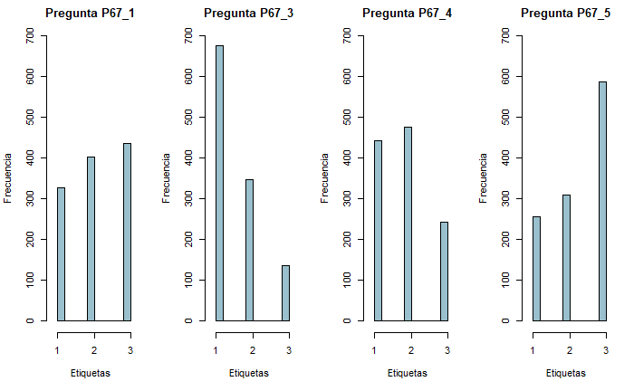

- $1$: Debería
- $2$: Depende
- $3$: No debería

```r
tabla <- table(migracion_de_mexico_clean$p54)
tabla
```

```
 11  12  13  14  16  17  18  19  20  24  25  26  28  29  31  32  33  34  37  39  41  97  98  99
438  22  29   2   1 101   4   4   1  10   9   3  21   7  13   7   3   7   8   1   1   1 405 100
```

```r
p54 <- data.frame(US = tabla[which(tabla == 438)],China = tabla[which(tabla == 22)])
p54
```

|  | US | China |
| --- | --- | --- |
| 11 | 438 | 22 |

```r
revisiones_migratorias_clean <- na.omit(revisiones_migratorias)
I_2015 <- data.frame(I_2015 = revisiones_migratorias_clean$`2015-01` + revisiones_migratorias_clean$`2015-02` + revisiones_migratorias_clean$`2015-03`)
II_2015 <- data.frame(II_2015 = revisiones_migratorias_clean$`2015-04` + revisiones_migratorias_clean$`2015-05` + revisiones_migratorias_clean$`2015-06`)
III_2015 <- data.frame(III_2015 = revisiones_migratorias_clean$`2015-07` + revisiones_migratorias_clean$`2015-08` + revisiones_migratorias_clean$`2015-09`)
IV_2015 <- data.frame(IV_2015 = revisiones_migratorias_clean$`2015-10` + revisiones_migratorias_clean$`2015-11` + revisiones_migratorias_clean$`2015-12`)
```

## **Obtención de Muestra**

- La inseguridad pública: causas y consecuencias.
- Víctimas, inculpados y sentenciados registrados.
- Encuesta Nacional de Migración.

## **Metodología**

Recopilar las bases de datos(formato .csv) de la página del Instituto Nacional de Estadística y Geografía(INEGI), Universidad Nacional Autónoma de México(UNAM) , para obtener indicadores de aumento de violencia en México.

## **Diagrama de Gantt**

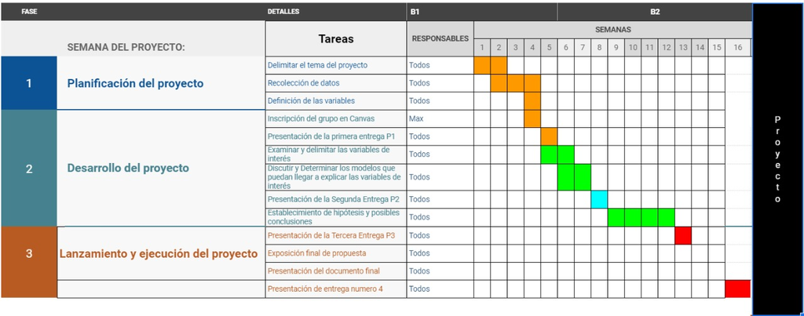

## **Referencias**

- Tapia Pérez, José (2013). La inseguridad pública: causas y consecuencias. El Cotidiano, (180),103-112.[fecha de Consulta 20 de Mayo de 2021]. ISSN: 0186-1840. Disponible en: https://www.redalyc.org/articulo.oa?id=32528338007
- Datos Abiertos de México - datos.gob.mx. (2021). Retrieved 10 May 2021, from https://datos.gob.mx/busca/dataset?tags=víctimas
- Biblioteca Los mexicanos vistos por sí mismos. Los grandes temas nacionales / Encuesta Nacional de Migración. (2021). Retrieved 10 May 2021, from http://www.losmexicanos.unam.mx/migracion/encuesta_nacional.html
- Morales Mena, A., & Caicedo, M. (2015, 25 agosto). Encuesta Nacional de Migración. Biblioteca Los Mexicanos vistos por sí mismos Los grandes temas nacionales. http://www.losmexicanos.unam.mx/migracion/encuesta_nacional.html https://datos.gob.mx/busca/dataset/migracion-mundial https://www.kaggle.com/zikazika/analysis-of-world-crime?select=Enrolment_in_Grade_1_of_primary_education1.csv
- Muñoz Rincón, D. (2021). ¿Cómo se dice:. Retrieved 17 May 2021, from https://www.upb.edu.co/es/central-blogs/ortografia/como-se-dice-migrante-emigrante-inmigrante
- Violencia. (2021). Retrieved 17 May 2021, from https://www.who.int/topics/violence/es/